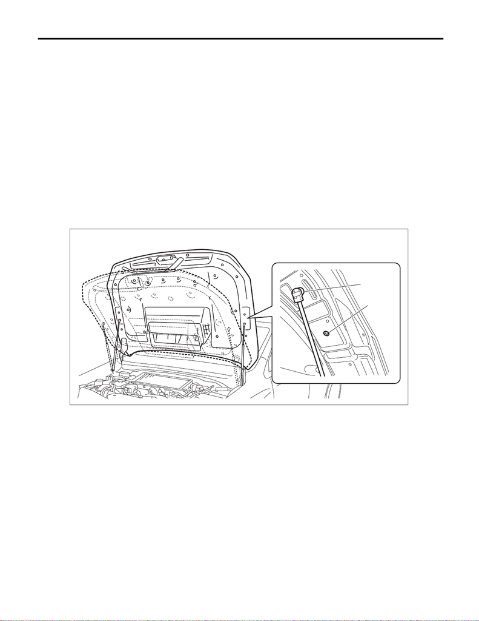

FS-22

Front Crossmember

FRONT SUSPENSION

3. Front Crossmember

A: REMOVAL

CAUTION:

For electric power steering model, be careful of the following items.

• The power steering control module continues to operate after the engine stops and calculates the

temperature in the control module. Therefore, before starting service of the power steering system

which requires disconnection of the connector, stop the engine and allow approx. 30 minutes until

the control module becomes cold.

• Be careful not to let any foreign matter (dust, water, oil, etc.) enter into the power steering control

module connector when removing or installing. If a foreign matter enters, completely remove it.

1) Lift up the vehicle, and then remove the front wheels.

2) Remove the under cover - front. <Ref. to EI-21, REMOVAL, Front Under Cover.>

3) Remove the universal joint assembly - steering. <Ref. to PS-21, REMOVAL, Universal Joint.>

4) Disconnect the ground cable from battery. <Ref. to NT-5, BATTERY, NOTE, Note.>

NOTE:

For models other than STI model, disconnect the ground terminal from battery sensor.

5) Change the hood stay location from (A) to (B) to open the front hood completely.

6) Remove the V-belt cover or the collector cover.

7) Disconnect the connector and harness clamp from power steering control module. (Electric power steer-

ing model)

8) Disconnect the power steering hose from the steering gearbox. (Hydraulic power steering model)

FS-00653

(A)

(B)

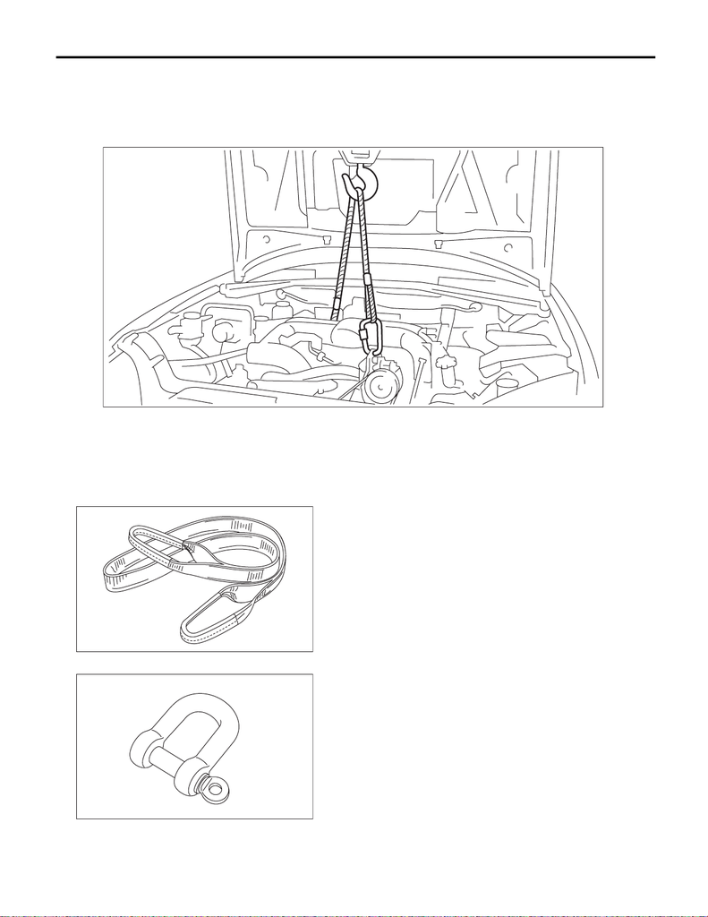

FS-23

Front Crossmember

FRONT SUSPENSION

9) Remove the engine mounting and the crossmember assembly.

(1) Support the engine with a lifting device and wire ropes.

(2) While lifting up the vehicle, also raise up the lifting device simultaneously.

CAUTION:

Be careful not to damage the vehicle with a lifting device or wire ropes.

(3) Raise up the lifting device, and lift the engine body by approx. 10 mm (0.39 in).

(4) Attach the sling belt so that it wraps around the both frames using the shackle.

CAUTION:

• Be sure to attach the sling belt to ensure safety in operation.

• Use a sling belt with the length of 2 m (6.6 ft), the width of 35 — 40 mm (1.38 — 1.57 in) and the load

capacity of 1 t (2205 lb) or more.

• Use a shackle with the load capacity of 0.5 t (1103 lb) or more.

ME-05105

FS-00324

FS-00325

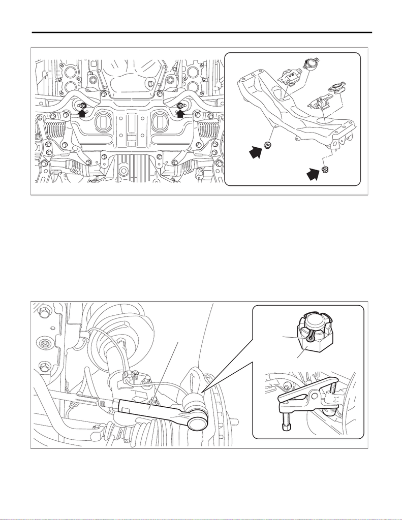

FS-24

Front Crossmember

FRONT SUSPENSION

(5) Remove the nuts which secure the engine mounting to the front crossmember assembly.

10) Remove the front crossmember support and the support plate - front crossmember. <Ref. to FS-29, RE-

MOVAL, Front Crossmember Support Plate.>

11) Remove the front exhaust pipe.

• STI model: <Ref. to EX(STI)-5, REMOVAL, Front Exhaust Pipe.>

• Except for STI model: <Ref. to EX(w/o STI)-9, REMOVAL, Front Exhaust Pipe.>

12) Remove the front stabilizer. <Ref. to FS-31, REMOVAL, Front Stabilizer.>

13) Disconnect the tie-rod end.

(1) Pull out the cotter pin (a).

(2) Remove the castle nut (b).

(3) Using a tie-rod ball joint puller, remove the tie-rod end (c).

Preparation tool:

Tie-rod ball joint puller

FS-00672

FS-00505

(a)

(b)

(c)

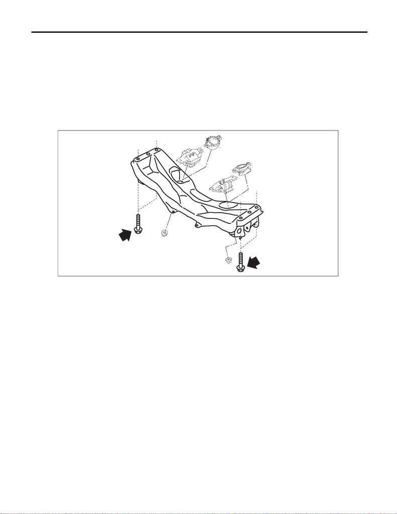

FS-25

Front Crossmember

FRONT SUSPENSION

14) Remove the front arm assembly. <Ref. to FS-37, REMOVAL, Front Arm.>

15) Remove the front crossmember assembly.

CAUTION:

• When lowering the transmission jack, make sure that the tie-rod end and the drive shaft boot do

not interfere. The drive shaft boot may be damaged.

• The front crossmember assembly is heavy. Make sure that it is firmly supported so that it is level.

(1) Support the front crossmember assembly from the bottom side using a transmission jack.

(2) Remove the bolts which secure the front crossmember assembly to the body.

(3) Lower the transmission jack slowly, and then lower the front crossmember assembly together with the

steering gearbox assembly.

(4) Remove the steering gearbox assembly from the front crossmember assembly.

FS-00673

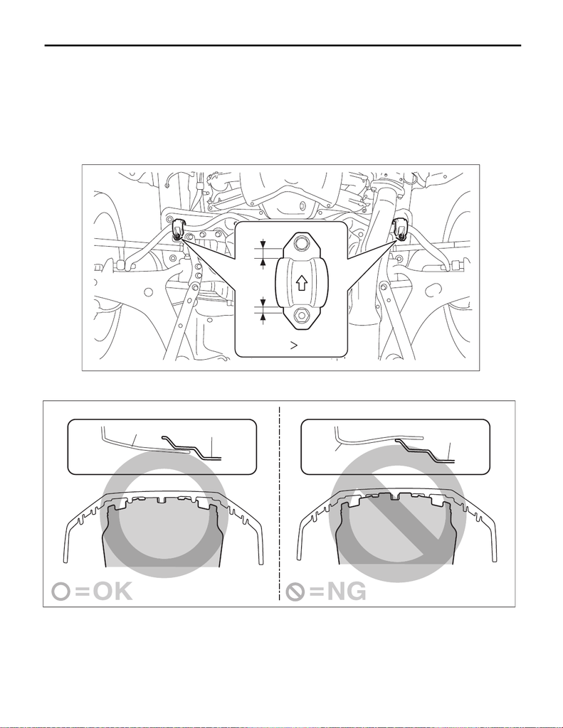

FS-26

Front Crossmember

FRONT SUSPENSION

B: INSTALLATION

CAUTION:

• When raising the transmission jack, make sure that the tie-rod end and the drive shaft boot do not

interfere. The drive shaft boot may be damaged.

• The front crossmember assembly is heavy. Make sure that it is firmly supported so that it is level.

• For parts which are not reusable, always use new parts.

• Always tighten the bushing in the state where the vehicle is at curb weight and the wheels are in

full contact with the ground.

• Install the clamp - stabilizer bushing with the arrow mark facing the front of the vehicle.

• Install the under cover - front so that the front end of the under cover (b) comes inside the bumper

face - front (a).

FS-00656

A

B

AB

EI-04291

(b)

(a)

(b)

(a)

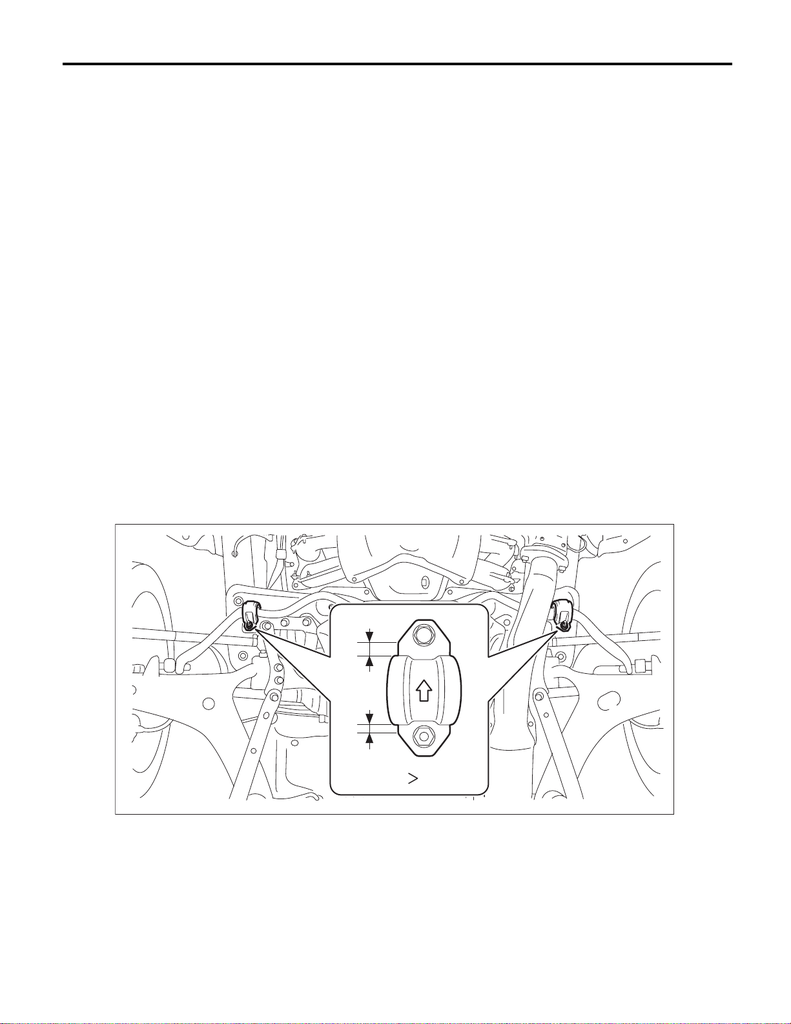

FS-27

Front Crossmember

FRONT SUSPENSION

1) Install the front crossmember assembly.

NOTE:

Check the crossmember for damage or cracks, and correct or replace if defective.

(1) Install the steering gearbox assembly to the front crossmember assembly.

(2) Install the bolts which secure the front crossmember assembly to the body.

Tightening torque:

Refer to “COMPONENT” of “General Description” for the tightening torque. <Ref. to FS-4, FRONT

SUSPENSION, COMPONENT, General Description.>

2) Install the front arm assembly.

NOTE:

When tightening the castle nut, tighten the castle nut to the specified torque first, then tighten it further but

within 60° until the hole in the ball stud is aligned with a slot in castle nut.

Tightening torque:

39 N·m (4.0 kgf-m, 28.8 ft-lb)

3) Insert a new cotter pin and secure the castle nut.

4) Install the tie-rod end.

NOTE:

When tightening the castle nut, tighten the castle nut to the specified torque first, then tighten it further but

within 60° until the hole in the ball stud is aligned with a slot in castle nut.

Tightening torque:

27 N·m (2.7 kgf-m, 19.9 ft-lb)

5) Insert a new cotter pin and secure the castle nut.

6) Install the front stabilizer.

CAUTION:

Install the clamp - stabilizer bushing with the arrow mark facing the front of the vehicle.

Tightening torque:

Refer to “COMPONENT” of “General Description” for the tightening torque. <Ref. to FS-4, FRONT

SUSPENSION, COMPONENT, General Description.>

7) Install the front exhaust pipe.

• STI model: <Ref. to EX(STI)-5, INSTALLATION, Front Exhaust Pipe.>

FS-00656

A

B

AB

[figure not shown]

FS-28

Front Crossmember

FRONT SUSPENSION

8) Install the front crossmember support and the support plate - front crossmember.

Tightening torque:

Refer to “COMPONENT” of “General Description” for the tightening torque. <Ref. to FS-4, FRONT

SUSPENSION, COMPONENT, General Description.>

9) Install the engine mounting and the crossmember assembly with new nuts.

CAUTION:

Be careful not to damage the vehicle with a lifting device or wire ropes.

Tightening torque:

Engine mounting — front crossmember assembly: 60 N·m (6.1 kgf-m, 44.3 ft-lb)

10) Install the power steering hose to the steering gearbox. (Hydraulic power steering model) <Ref. to PS-72,

INSTALLATION, Pipe Assembly.>

11) Install the connector and harness clamp to the power steering control module. (Electric power steering

model) <Ref. to PS-84, INSTALLATION, Power Steering Control Module.>

12) Install the V-belt cover or the collector cover.

Tightening torque:

V-belt cover: 7.5 N·m (0.8 kgf-m, 5.5 ft-lb)

13) Change the hood stay location to support the front hood at ordinary position.

Tightening torque:

7.5 N·m (0.8 kgf-m, 5.5 ft-lb)

14) Install the universal joint assembly - steering. <Ref. to PS-22, INSTALLATION, Universal Joint.>

15) Install the under cover - front. <Ref. to EI-22, INSTALLATION, Front Under Cover.>

16) Install the front wheels and lower the vehicle.

Tightening torque:

120 N·m (12.2 kgf-m, 88.5 ft-lb)

17) Connect the battery ground terminal. <Ref. to NT-5, BATTERY, NOTE, Note.>

NOTE:

For models other than STI model, connect the ground terminal to battery sensor.

18) Inspect the wheel alignment and adjust if necessary.

• Inspection: <Ref. to FS-10, INSPECTION, Wheel Alignment.>

• Adjustment: <Ref. to FS-15, ADJUSTMENT, Wheel Alignment.>

CAUTION:

When the wheel alignment has been adjusted, perform “VDC sensor midpoint setting mode” of the

VDC. <Ref. to VDC-16, ADJUSTMENT, VDC Control Module and Hydraulic Control Unit (VDCCM&H/

U).>

19) Perform reinitialization of the auto headlight beam leveler system. (Model with auto headlight beam lev-

eler) <Ref. to LI-16, PROCEDURE, Auto Headlight Beam Leveler System.>